# Chapter_3

## Exercises with `arrange()`

#### Sort all missing values to the top

```r
flights %>% arrange(desc(is.na(dep_time)), dep_time)
```

```
## # A tibble: 336,776 x 19
##     year month   day dep_time sched_dep_time dep_delay arr_time
##    <int> <int> <int>    <int>          <int>     <dbl>    <int>
##  1  2013     1     1       NA           1630        NA       NA
##  2  2013     1     1       NA           1935        NA       NA
##  3  2013     1     1       NA           1500        NA       NA
##  4  2013     1     1       NA            600        NA       NA
##  5  2013     1     2       NA           1540        NA       NA
##  6  2013     1     2       NA           1620        NA       NA
##  7  2013     1     2       NA           1355        NA       NA
##  8  2013     1     2       NA           1420        NA       NA
##  9  2013     1     2       NA           1321        NA       NA
## 10  2013     1     2       NA           1545        NA       NA
## # ... with 336,766 more rows, and 12 more variables: sched_arr_time <int>,
## #   arr_delay <dbl>, carrier <chr>, flight <int>, tailnum <chr>,
## #   origin <chr>, dest <chr>, air_time <dbl>, distance <dbl>, hour <dbl>,
## #   minute <dbl>, time_hour <dttm>
```

#### Sort `flights` to find the most delayed flights. Find the flights that left earliest.

```r
#Most delayed
flights %>% arrange(desc(dep_delay))

#Left earliest
flights %>% arrange(dep_delay)
```

#### Sort flights to find the fastest flight

```r
flights %>% arrange(air_time) %>%
  select(origin, dest, air_time) %>%
  head()
```

```
## # A tibble: 6 x 3
##   origin dest  air_time
##   <chr>  <chr>    <dbl>
## 1 EWR    BDL         20
## 2 EWR    BDL         20
## 3 EWR    BDL         21
## 4 EWR    PHL         21
## 5 EWR    BDL         21
## 6 EWR    PHL         21
```

#### Which flights traveled the longest? Which traveled the shortest?

```r
flights %>% arrange(desc(distance)) %>%
  select(origin, dest, distance) %>%
  head()
```

```
## # A tibble: 6 x 3
##   origin dest  distance
##   <chr>  <chr>    <dbl>
## 1 JFK    HNL       4983
## 2 JFK    HNL       4983
## 3 JFK    HNL       4983
## 4 JFK    HNL       4983
## 5 JFK    HNL       4983
## 6 JFK    HNL       4983
```

```r
flights %>% arrange(distance) %>%
  select(origin, dest, distance) %>%
  head()
```

```
## # A tibble: 6 x 3
##   origin dest  distance
##   <chr>  <chr>    <dbl>
## 1 EWR    LGA         17
## 2 EWR    PHL         80
## 3 EWR    PHL         80
## 4 EWR    PHL         80
## 5 EWR    PHL         80
## 6 EWR    PHL         80
```

## Exercises for `select()`

#### Ways to select `dep_time, dep_delay, arr_time, arr_delay`

```r
flights %>% select(dep_time, dep_delay, arr_time, arr_delay)

flights %>% select(starts_with("dep_"), starts_with("arr_"))

flights %>% select(ends_with("time"), ends_with("delay"))
```

`ends_with` does not work well since it returns several variables we are not interested in.

#### What does `one_of()`do?

Select variables based on a character vector instead of unquoted variable names.

```r
flights %>% select(one_of(c("year", "month")))
```

```
## # A tibble: 336,776 x 2
##     year month
##    <int> <int>
##  1  2013     1
##  2  2013     1
##  3  2013     1
##  4  2013     1
##  5  2013     1
##  6  2013     1
##  7  2013     1
##  8  2013     1
##  9  2013     1
## 10  2013     1
## # ... with 336,766 more rows
```

#### Does the result of running the following code surprise you? How do the select helpers deal with case by default? How can you change that default?

```r
flights %>% select(contains("TIME"))
```

```
## # A tibble: 336,776 x 6
##    dep_time sched_dep_time arr_time sched_arr_time air_time
##       <int>          <int>    <int>          <int>    <dbl>
##  1      517            515      830            819      227
##  2      533            529      850            830      227
##  3      542            540      923            850      160
##  4      544            545     1004           1022      183
##  5      554            600      812            837      116
##  6      554            558      740            728      150
##  7      555            600      913            854      158
##  8      557            600      709            723       53
##  9      557            600      838            846      140
## 10      558            600      753            745      138
## # ... with 336,766 more rows, and 1 more variable: time_hour <dttm>
```

`contains()` does not care about upper or lower case letters. This can be changed by adding the argument `contains("TIME", ingnore.case = F)`.

## Exercises for `mutate()`

```r
#test
flights_sml <- flights %>%
  select(year:day,
         ends_with("delay"),
         distance,
         air_time)
```

#### Convert `dep_time` and `sched_dep_time` to a more convenient representation of numbers of minutes since midnight.

```r
flights %>% transmute(dep_time = (dep_time %/% 100)*60 + dep_time %% 100,
                      sched_dep_time = (sched_dep_time %/% 100)*60 + dep_time %% 100)
```

```
## # A tibble: 336,776 x 2
##    dep_time sched_dep_time
##       <dbl>          <dbl>
##  1      317            317
##  2      333            333
##  3      342            342
##  4      344            344
##  5      354            414
##  6      354            354
##  7      355            415
##  8      357            417
##  9      357            417
## 10      358            418
## # ... with 336,766 more rows
```

#### Compare `air_time` with `arr_time - dep_time`

```r
flights %>% transmute(air_time,
                      diff_time = arr_time - dep_time)
```

```
## # A tibble: 336,776 x 2
##    air_time diff_time
##       <dbl>     <int>
##  1      227       313
##  2      227       317
##  3      160       381
##  4      183       460
##  5      116       258
##  6      150       186
##  7      158       358
##  8       53       152
##  9      140       281
## 10      138       195
## # ... with 336,766 more rows
```

We observed a difference because `arr_time` and `dep_time` are not on the format of minutes since midnight. We can fix it in the following way:

```r
time2mins <- function(t){
  #Trasforms timepoint to minuttes since midnight
  (t %/% 100 * 60 + t %% 100) %% 1440
}

flights %>% transmute(air_time,
                      arr_time = time2mins(arr_time),
                      dep_time = time2mins(dep_time),
                      air_time2 = arr_time - dep_time,
                      diff = air_time - air_time2)
```

```
## # A tibble: 336,776 x 5
##    air_time arr_time dep_time air_time2  diff
##       <dbl>    <dbl>    <dbl>     <dbl> <dbl>
##  1      227      510      317       193    34
##  2      227      530      333       197    30
##  3      160      563      342       221   -61
##  4      183      604      344       260   -77
##  5      116      492      354       138   -22
##  6      150      460      354       106    44
##  7      158      553      355       198   -40
##  8       53      429      357        72   -19
##  9      140      518      357       161   -21
## 10      138      473      358       115    23
## # ... with 336,766 more rows
```

#### Compare `dep_time, sched_dep_time, dep_delay`

```r
flights_sml <- flights %>%
  select(dep_time, sched_dep_time, dep_delay)

flights_sml %>% transmute(dep_time = time2mins(dep_time),
                       sched_dep_time = time2mins(sched_dep_time),
                       dep_delay,
                       diff_time = dep_time - (sched_dep_time + dep_delay))
```

```
## # A tibble: 336,776 x 4
##    dep_time sched_dep_time dep_delay diff_time
##       <dbl>          <dbl>     <dbl>     <dbl>
##  1      317            315         2         0
##  2      333            329         4         0
##  3      342            340         2         0
##  4      344            345        -1         0
##  5      354            360        -6         0
##  6      354            358        -4         0
##  7      355            360        -5         0
##  8      357            360        -3         0
##  9      357            360        -3         0
## 10      358            360        -2         0
## # ... with 336,766 more rows
```

#### Find the 10 most delayed flights using a ranking function.

`min_rank` will give rank in an increasing order, i.e. the lowest value will have rank 1. `min_rank(desc())` changes the sign of the variable and thus gives rank in a decreasing order.

```r
flights_delayed <- flights %>% mutate(dep_delayed_rank = min_rank(desc(dep_delay)))
flights_delayed %>% filter(dep_delayed_rank <= 10) %>% arrange(dep_delayed_rank)
```

```
## # A tibble: 10 x 20
##     year month   day dep_time sched_dep_time dep_delay arr_time
##    <int> <int> <int>    <int>          <int>     <dbl>    <int>
##  1  2013     1     9      641            900      1301     1242
##  2  2013     6    15     1432           1935      1137     1607
##  3  2013     1    10     1121           1635      1126     1239
##  4  2013     9    20     1139           1845      1014     1457
##  5  2013     7    22      845           1600      1005     1044
##  6  2013     4    10     1100           1900       960     1342
##  7  2013     3    17     2321            810       911      135
##  8  2013     6    27      959           1900       899     1236
##  9  2013     7    22     2257            759       898      121
## 10  2013    12     5      756           1700       896     1058
## # ... with 13 more variables: sched_arr_time <int>, arr_delay <dbl>,
## #   carrier <chr>, flight <int>, tailnum <chr>, origin <chr>, dest <chr>,
## #   air_time <dbl>, distance <dbl>, hour <dbl>, minute <dbl>,
## #   time_hour <dttm>, dep_delayed_rank <int>
```

#### 1:3 + 1:10

R recycles the shortest vector.

## Excercises for `summarize()`

#### Come up with another approach that will give you the same output as `not_cancelled %>% count(dest)` and `not_cancelled %>% count(tailnum, wt = distance)` (without using `count()`)

```r
not_cancelled <- flights %>%
  filter(!is.na(dep_delay), !is.na(arr_delay))

not_cancelled %>% group_by(dest) %>% summarise(n = n()) %>% arrange(desc(n))
```

```
## # A tibble: 104 x 2
##    dest      n
##    <chr> <int>
##  1 ATL   16837
##  2 ORD   16566
##  3 LAX   16026
##  4 BOS   15022
##  5 MCO   13967
##  6 CLT   13674
##  7 SFO   13173
##  8 FLL   11897
##  9 MIA   11593
## 10 DCA    9111
## # ... with 94 more rows
```

```r
not_cancelled %>% group_by(tailnum) %>% summarize(n = sum(distance))
```

```
## # A tibble: 4,037 x 2
##    tailnum      n
##    <chr>    <dbl>
##  1 D942DN    3418
##  2 N0EGMQ  239143
##  3 N10156  109664
##  4 N102UW   25722
##  5 N103US   24619
##  6 N104UW   24616
##  7 N10575  139903
##  8 N105UW   23618
##  9 N107US   21677
## 10 N108UW   32070
## # ... with 4,027 more rows
```

#### Look at the number of canceled flights per day. Is there a pattern? Is the proportion of canceled flights related to the average delay?

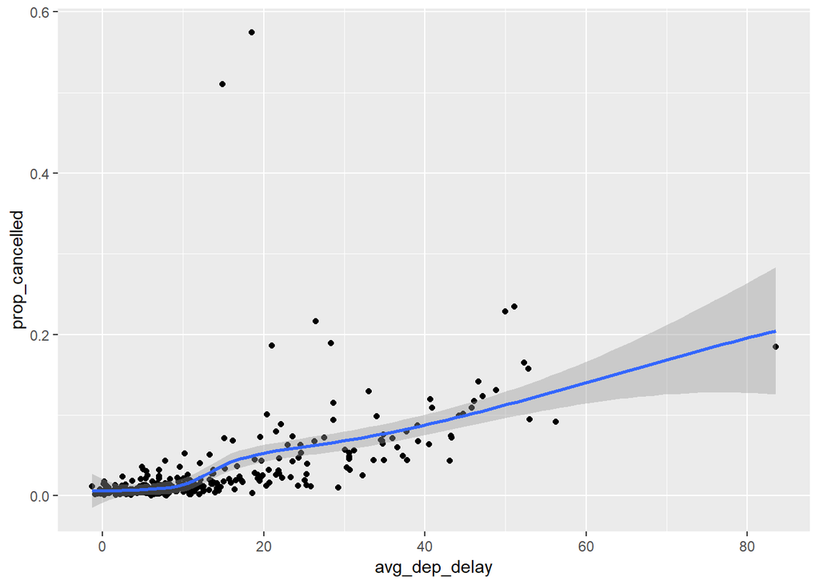

```r
cancelled <- flights %>%
  mutate(cancelled = is.na(dep_delay) | is.na(arr_delay)) %>%
  group_by(year, month, day) %>%
  summarise(prop_cancelled = mean(cancelled),
            avg_dep_delay = mean(dep_delay, na.rm = T))


cancelled %>% ggplot(aes(x = avg_dep_delay, y = prop_cancelled)) +
  geom_point() + geom_smooth()
```

Days that have big delays also have a higher proportion on cancelled flights.

#### Which carrier has the worst delays? Challenge: can you disentangle the effects of bad airports vs. bad carriers? Why/why not? (Hint: think about `flights %>% group_by(carrier, dest) %>% summarise(n())`)

```r
#Worst carriers
colnames(flights)
```

```
##  [1] "year"           "month"          "day"            "dep_time"
##  [5] "sched_dep_time" "dep_delay"      "arr_time"       "sched_arr_time"
##  [9] "arr_delay"      "carrier"        "flight"         "tailnum"
## [13] "origin"         "dest"           "air_time"       "distance"
## [17] "hour"           "minute"         "time_hour"
```

```r
flights %>% group_by(carrier) %>%
  summarise(delay = mean(arr_delay, na.rm = T)) %>%
  arrange(desc(delay))
```

```
## # A tibble: 16 x 2
##    carrier   delay
##    <chr>     <dbl>
##  1 F9       21.9
##  2 FL       20.1
##  3 EV       15.8
##  4 YV       15.6
##  5 OO       11.9
##  6 MQ       10.8
##  7 WN        9.65
##  8 B6        9.46
##  9 9E        7.38
## 10 UA        3.56
## 11 US        2.13
## 12 VX        1.76
## 13 DL        1.64
## 14 AA        0.364
## 15 HA       -6.92
## 16 AS       -9.93
```

```r
airlines %>% filter(carrier %in% c("F9", "EV", "YV"))
```

```
## # A tibble: 3 x 2
##   carrier name
##   <chr>   <chr>
## 1 EV      ExpressJet Airlines Inc.
## 2 F9      Frontier Airlines Inc.
## 3 YV      Mesa Airlines Inc.
```

```r
flights %>%
  group_by(carrier, dest) %>%
  summarise(n = n(),
            delay = mean(arr_delay, na.rm = T)) %>%
  arrange(desc(n))
```

```
## # A tibble: 314 x 4
## # Groups:   carrier [16]
##    carrier dest      n   delay
##    <chr>   <chr> <int>   <dbl>
##  1 DL      ATL   10571   7.42
##  2 US      CLT    8632   2.44
##  3 AA      DFW    7257  -0.490
##  4 AA      MIA    7234  -1.88
##  5 UA      ORD    6984   6.07
##  6 UA      IAH    6924   3.73
##  7 UA      SFO    6819   3.14
##  8 B6      FLL    6563  12.0
##  9 B6      MCO    6472  11.5
## 10 AA      ORD    6059  -0.714
## # ... with 304 more rows
```

A nice way to attach mean by group to the original data frame:

```r
flights2 <- flights %>%
  group_by(carrier) %>%
  mutate(delay_carrier = mean(arr_delay, na.rm = T))

head(flights2)
```

```
## # A tibble: 6 x 20
## # Groups:   carrier [4]
##    year month   day dep_time sched_dep_time dep_delay arr_time
##   <int> <int> <int>    <int>          <int>     <dbl>    <int>
## 1  2013     1     1      517            515         2      830
## 2  2013     1     1      533            529         4      850
## 3  2013     1     1      542            540         2      923
## 4  2013     1     1      544            545        -1     1004
## 5  2013     1     1      554            600        -6      812
## 6  2013     1     1      554            558        -4      740
## # ... with 13 more variables: sched_arr_time <int>, arr_delay <dbl>,
## #   carrier <chr>, flight <int>, tailnum <chr>, origin <chr>, dest <chr>,
## #   air_time <dbl>, distance <dbl>, hour <dbl>, minute <dbl>,
## #   time_hour <dttm>, delay_carrier <dbl>
```

#### For each plane, count the number of flights before the first delay of greater than one hour.

```r
flights %>%
  group_by(flight) %>%
  summarise(n_delay = sum(arr_delay > 60, na.rm = T)) %>%
  arrange(desc(n_delay))
```

```
## # A tibble: 3,844 x 2
##    flight n_delay
##     <int>   <int>
##  1    527      91
##  2    415      88
##  3   4131      86
##  4    695      80
##  5   4333      80
##  6    985      76
##  7    359      75
##  8    257      74
##  9   4543      74
## 10     29      70
## # ... with 3,834 more rows
```

## Exercises for `Grouped mutates`